# SARIMA

Miguel G.

3/11/2022

# Modelo SARIMA

Vamos analizar el valor de la producción de la industria alimentaria de Jalisco para realizar un prónostico.

Iniciamos de la manera estádar

```r
rm(list=ls())

setwd("C:/Users/Miike/OneDrive - ITESO/01 Documentos/O2022/pronosticos/sarima")

library(readxl)
library(forecast)
library(tidyverse)
library(lmtest)
library(tseries)

datos <- read_excel("produccion_alim.xlsx")

alimentos <- ts(datos$Valores, start = c(2013,1), frequency = 12)
```

Analizamos graficamente la serie

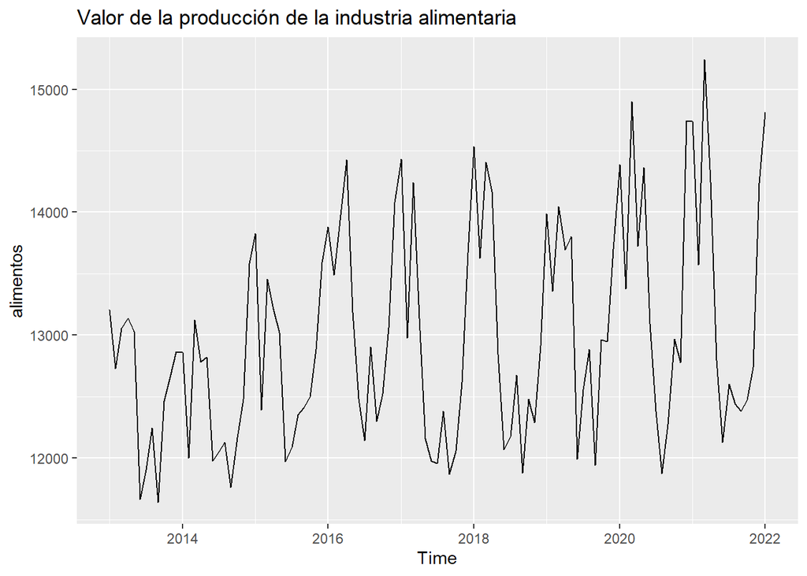

```r
autoplot(alimentos)+
  ggtitle("Valor de la producción de la industria alimentaria")
```

La serie muestra un patrón estacional, debemos usar un modelo SARIMA

## Orden de integración

Buscamos el orden de integración.

Para calcular las diferencias regulares, utilizaba la función *diff()*, para calcular las diferencias estacionales, uso la mismo función, indicando el rezago sobre el cual debe calcular las diferencias.

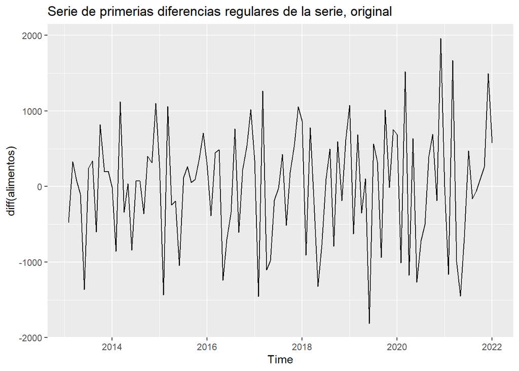

```r
autoplot( diff(alimentos) )+
  ggtitle("Serie de primerias diferencias regulares de la serie, original")
```

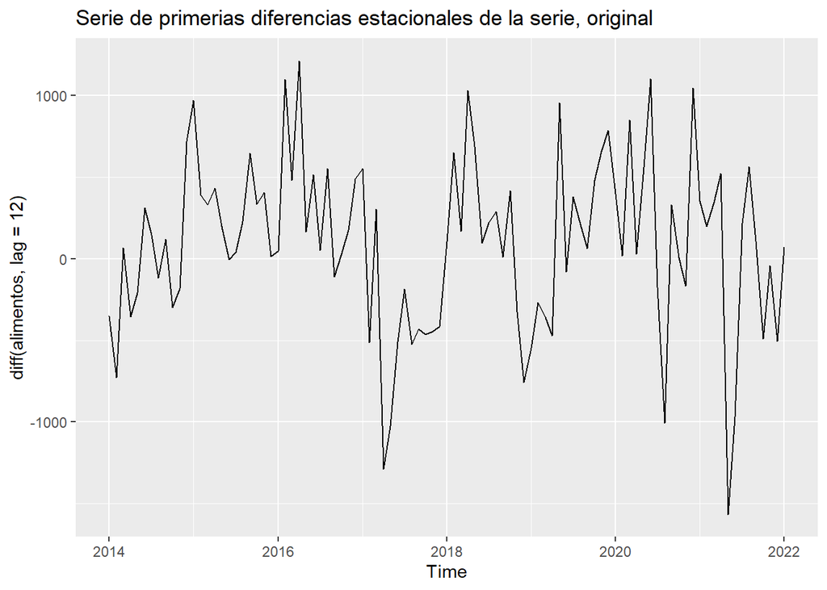

```r
autoplot( diff(alimentos, lag = 12) )+
  ggtitle("Serie de primerias diferencias estacionales de la serie, original")
```

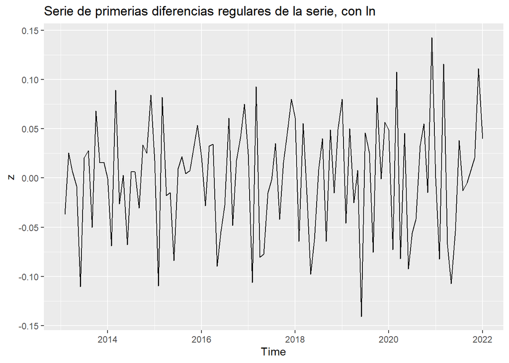

```r
z <- diff(log(alimentos))

autoplot( z )+
  ggtitle("Serie de primerias diferencias regulares de la serie, con ln")
```

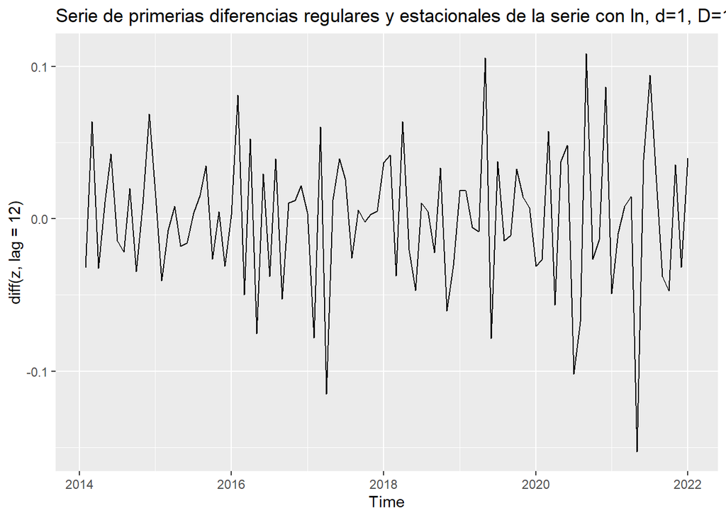

```r
autoplot( diff(z, lag = 12) )+
  ggtitle("Serie de primerias diferencias regulares y estacionales de la serie con ln, d=1, D=1")
```

Prueba Dickey-Fuller

```r
#Sobre la serie original

adf.test(alimentos)
```

```
##
##  Augmented Dickey-Fuller Test
##
## data:  alimentos
## Dickey-Fuller = -7.768, Lag order = 4, p-value = 0.01
## alternative hypothesis: stationary
```

```r
#Sobre la serie en primeras diferencias
adf.test(z)
```

```
##
##  Augmented Dickey-Fuller Test
##
## data:  z
## Dickey-Fuller = -4.7598, Lag order = 4, p-value = 0.01
## alternative hypothesis: stationary
```

```r
#Sobre la serie en primerias diferencias estacionales
adf.test(diff(log(alimentos), lag = 12))
```

```
##
##  Augmented Dickey-Fuller Test
##
## data:  diff(log(alimentos), lag = 12)
## Dickey-Fuller = -3.8347, Lag order = 4, p-value = 0.02025
## alternative hypothesis: stationary
```

```r
#Sobre la serie de primeras diferencias estacionales y regulares
adf.test(diff(z, lag = 12))
```

```
##
##  Augmented Dickey-Fuller Test
##
## data:  diff(z, lag = 12)
## Dickey-Fuller = -7.0735, Lag order = 4, p-value = 0.01
## alternative hypothesis: stationary
```

## Autocorrelación

Analizamos la autocorrelacion de la serie de primeras diferencias en logaritmo natural.

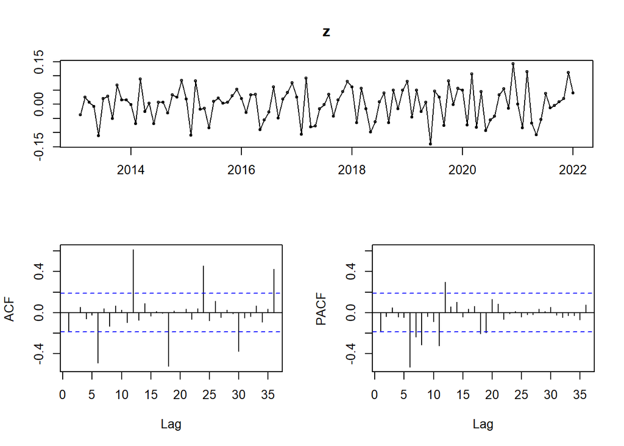

```r
tsdisplay(z)
```

El modelo SARIMA propuesto es $ARIMA(p,d,q)(P,D,Q)[12]=ARIMA(1,1,1)(1,0,0)[12]$, con logaritmo natural.

## Modelo y pronostico

Estimamos el modelo.

La parte no estacional la establesco con la opción *order=c()*, y la parte estacional con la opción *seasonal=c()*. Recuerda que la opción *lambda=0* es para indicarle que realice la transformación de logaritmo natural.

```r
modelo_1 <- Arima(alimentos, order=c(1,1,1), seasonal = c(1,0,0), lambda = 0)

modelo_2 <- Arima(alimentos, order=c(1,1,1), seasonal = c(1,0,0), lambda = 0, include.constant = TRUE)
```

Revisamos el ajuste del modelo. Seleccionamos el modelo con el menor criterio de información, nos quedamos con el modelo 1.

```r
# Resultados
modelo_1
```

```
## Series: alimentos
## ARIMA(1,1,1)(1,0,0)[12]
## Box Cox transformation: lambda= 0
##
## Coefficients:
##          ar1      ma1    sar1
##       0.4343  -0.9833  0.7529
## s.e.  0.0941   0.0214  0.0623
##
## sigma^2 = 0.001312:  log likelihood = 201.33
## AIC=-394.67   AICc=-394.28   BIC=-383.94
```

```r
modelo_2
```

```
## Series: alimentos
## ARIMA(1,1,1)(1,0,0)[12] with drift
## Box Cox transformation: lambda= 0
##
## Coefficients:
##          ar1      ma1    sar1  drift
##       0.4196  -1.0000  0.7484  6e-04
## s.e.  0.0909   0.0169  0.0625  4e-04
##
## sigma^2 = 0.001291:  log likelihood = 202.37
## AIC=-394.75   AICc=-394.16   BIC=-381.33
```

```r
# Coeficientes
coeftest(modelo_1)
```

```
##
## z test of coefficients:
##
##       Estimate Std. Error  z value  Pr(>|z|)
## ar1   0.434342   0.094114   4.6151  3.93e-06 ***
## ma1  -0.983305   0.021430 -45.8841 < 2.2e-16 ***
## sar1  0.752936   0.062292  12.0872 < 2.2e-16 ***
## ---
## Signif. codes:  0 '***' 0.001 '**' 0.01 '*' 0.05 '.' 0.1 ' ' 1
```

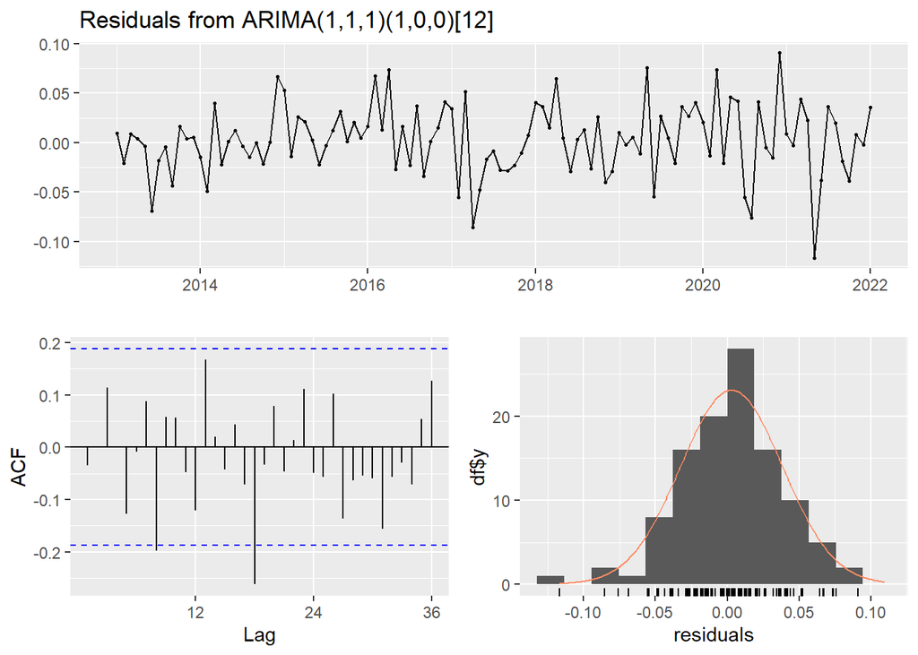

```
##
##  Ljung-Box test
##
## data:  Residuals from ARIMA(1,1,1)(1,0,0)[12]
## Q* = 27.154, df = 19, p-value = 0.1011
##
## Model df: 3.   Total lags used: 22
```

```r
#Prueba de ruido blanco
checkresiduals(modelo_1)
```

Realizamos el pronóstico

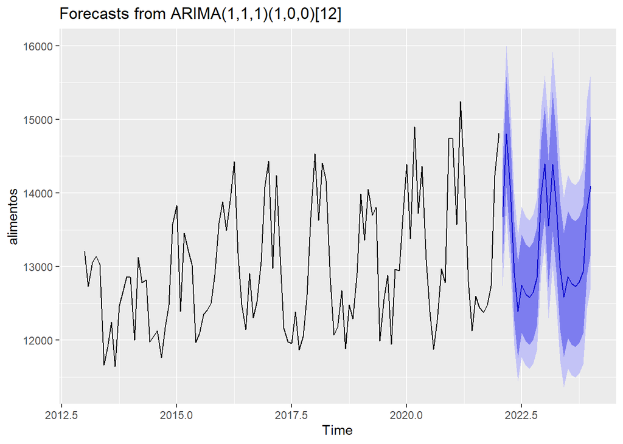

```r
pronostico <- forecast(modelo_1, h=24)

autoplot(pronostico)
```

Contrastamos con la funcion auto.arima y REVISAR SU AJUSTE

```r
modelo_auto <- auto.arima(alimentos, ic="bic")

pronostico2 <- forecast(modelo_auto, h=24)
```

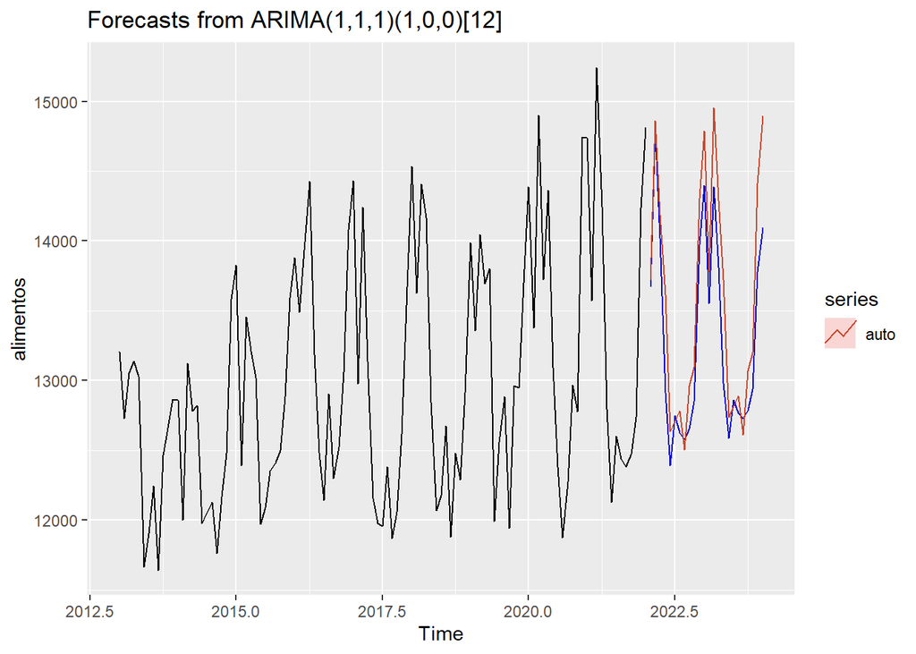

```r
autoplot(pronostico, PI=F)+
  autolayer(pronostico2, series="auto", PI=F)
```